```python
from IPython.display import Image, display
import pandas as pd
import numpy as np
from sklearn import metrics
from sklearn.metrics import confusion_matrix
import itertools
import os
import shutil
from random import randint
import random
import glob
import matplotlib.pyplot as plt
import warnings
import pathlib
import pickle
from PIL import Image, ImageOps
from sklearn.utils import shuffle
warnings.simplefilter(action='ignore', category=FutureWarning)
os.environ['TF_CPP_MIN_LOG_LEVEL'] = '2'
warnings.filterwarnings('ignore')
%matplotlib inline
```

# Data Processing

```python
import os

# folder path
dir_path = r'C:\\Users\\רועי\\data\\NG-vs-OK\\OK-20220428T174909Z-001\\OK'
count_OK = 0
# Iterate directory
for path in os.listdir(dir_path):
    # check if current path is a file
    if os.path.isfile(os.path.join(dir_path, path)):
        count_OK += 1
print('File count:', count_OK)
```

```
File count: 267
```

```python
import os

# folder path
dir_path = r'C:\\Users\\רועי\\data\\NG-vs-OK\\NG-20220428T174957Z-001\\NG'
count_NG = 0
# Iterate directory
for path in os.listdir(dir_path):
    # check if current path is a file
    if os.path.isfile(os.path.join(dir_path, path)):
        count_NG += 1
print('File count:', count_NG)
```

```
File count: 24
```

```python
import seaborn as sns
d = {'class': ['OK', 'NG'], 'count': [count_OK, count_NG] }
df = pd.DataFrame(data=d)
df
```

|  | class | count |
| --- | --- | --- |
| 0 | OK | 267 |
| 1 | NG | 24 |

```python
if os.path.isdir('C:\\Users\\רועי\\data\\NG-vs-OK\\DA1') is False:
    os.makedirs('C:\\Users\רועי\\data\\NG-vs-OK\\DA1')
os.chdir('../../')
```

```python
os.chdir('C:\\Users\\רועי\\data\\NG-vs-OK\\NG-20220428T174957Z-001\\NG')
if os.path.isdir('C:\\Users\\רועי\\data\\NG-vs-OK\\DA1\\NG') is False:
    os.makedirs('C:\\Users\רועי\\data\\NG-vs-OK\\DA1\\NG')

    for i in random.sample(glob.glob('*'), count_NG):
        shutil.copy(i, 'C:\\Users\\רועי\\data\\NG-vs-OK\\DA1\\NG')
os.chdir('../../')


os.chdir('C:\\Users\\רועי\\data\\NG-vs-OK\\OK-20220428T174909Z-001\\OK')
if os.path.isdir('C:\\Users\\רועי\\data\\NG-vs-OK\\DA1\\OK') is False:
    os.makedirs('C:\\Users\רועי\\data\\NG-vs-OK\\DA1\\OK')

    for i in random.sample(glob.glob('*'), count_OK):
        shutil.copy(i, 'C:\\Users\\רועי\\data\\NG-vs-OK\\DA1\\OK')
os.chdir('../../')
```

```python
 # importing os module
import os

# Function to rename multiple files
def main():

    folder = "C:\\Users\\רועי\\data\\NG-vs-OK\\DA1\\NG"
    for count, filename in enumerate(os.listdir(folder)):
        dst = f"NG{str(count)}.jpg"
        src =f"{folder}/{filename}"  # foldername/filename, if .py file is outside folder
        dst =f"{folder}/{dst}"

        # rename() function will
        # rename all the files
        os.rename(src, dst)

 # Driver Code
if __name__ == '__main__':

    # Calling main() function
    main()
```

```python
 # importing os module
import os

# Function to rename multiple files
def main():

    folder = "C:\\Users\\רועי\\data\\NG-vs-OK\\DA1\\OK"
    for count, filename in enumerate(os.listdir(folder)):
        dst = f"OK{str(count)}.jpg"
        src =f"{folder}/{filename}"  # foldername/filename, if .py file is outside folder
        dst =f"{folder}/{dst}"

        # rename() function will
        # rename all the files
        os.rename(src, dst)

 # Driver Code
if __name__ == '__main__':

    # Calling main() function
    main()
```

- Let's load in an arbitrary image:

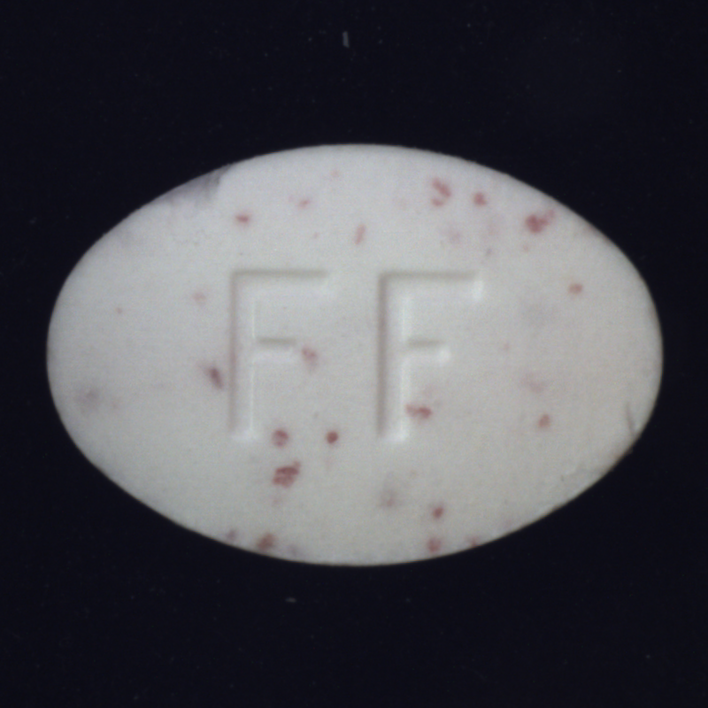

```python
src_img = Image.open('C:\\Users\\רועי\\data\\NG-vs-OK\\DA1\\NG\\NG0.jpg')
display(src_img)
```

- Here's the shape (width, height, color channels):

```python
np.array(src_img).shape
```

```
(800, 800, 3)
```

```python
281 * 300 * 3
```

```
252900
```

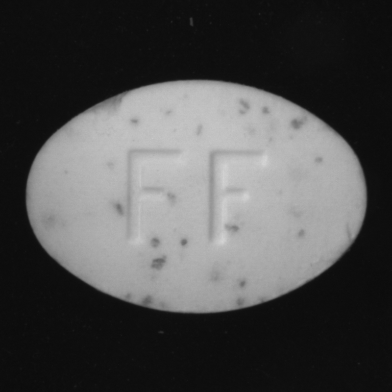

```python
gray_img = ImageOps.grayscale(src_img)
display(gray_img)
```

```python
np.array(gray_img).shape
```

```
(800, 800)
```

```python
281 * 300
```

```
84300
```

- It's still a lot, so let's resize the image to something smaller
- Let's say 28x28:

```python
gray_resized_img = gray_img.resize(size=(28, 28))
display(gray_resized_img)
```

[output not shown]

```python
np.array(gray_resized_img).shape
```

```
(28, 28)
```

- Much less features:

```python
28 * 28
```

```
784
```

- This is how you can flatten the image and store it as an array:

```python
np.ravel(gray_resized_img)
```

```
array([ 14,  14,  14,  14,  14,  14,  14,  14,  15,  14,  14,  15,  15,
        15,  15,  15,  14,  14,  15,  15,  14,  15,  15,  15,  14,  14,
        13,  13,  14,  14,  14,  14,  14,  14,  14,  14,  15,  14,  14,
        15,  15,  19,  15,  14,  14,  14,  15,  15,  15,  16,  17,  16,
        15,  14,  13,  13,  14,  14,  14,  14,  15,  15,  15,  14,  15,
        15,  15,  15,  14,  15,  15,  14,  14,  15,  14,  15,  16,  17,
        17,  17,  15,  14,  13,  13,  14,  14,  14,  14,  14,  15,  15,
        14,  14,  14,  15,  15,  15,  15,  15,  15,  15,  15,  15,  15,
        16,  17,  17,  17,  15,  14,  13,  13,  14,  14,  14,  14,  15,
        15,  15,  15,  15,  15,  14,  12,  11,  10,  10,  11,  12,  14,
        15,  15,  15,  16,  17,  16,  15,  14,  13,  13,  14,  14,  14,
        14,  14,  15,  15,  14,  12,  10,  18,  34,  49,  57,  57,  49,
        34,  19,  11,  11,  14,  15,  15,  15,  14,  14,  13,  13,  14,
        14,  14,  15,  15,  14,  11,  15,  44, 104, 149, 171, 182, 185,
       186, 180, 168, 146, 109,  58,  18,   9,  14,  14,  14,  14,  14,
```

[output cut: 46 more lines]

- The values aren't in an ideal range (0-255)
- Neural network model prefers 0-1 range
- Let's transform it:

```python
img_final = np.ravel(gray_resized_img) / 255.0
```

```python
img_final
```

```
array([0.05490196, 0.05490196, 0.05490196, 0.05490196, 0.05490196,
       0.05490196, 0.05490196, 0.05490196, 0.05882353, 0.05490196,
       0.05490196, 0.05882353, 0.05882353, 0.05882353, 0.05882353,
       0.05882353, 0.05490196, 0.05490196, 0.05882353, 0.05882353,
       0.05490196, 0.05882353, 0.05882353, 0.05882353, 0.05490196,
       0.05490196, 0.05098039, 0.05098039, 0.05490196, 0.05490196,
       0.05490196, 0.05490196, 0.05490196, 0.05490196, 0.05490196,
       0.05490196, 0.05882353, 0.05490196, 0.05490196, 0.05882353,
       0.05882353, 0.0745098 , 0.05882353, 0.05490196, 0.05490196,
       0.05490196, 0.05882353, 0.05882353, 0.05882353, 0.0627451 ,
       0.06666667, 0.0627451 , 0.05882353, 0.05490196, 0.05098039,
       0.05098039, 0.05490196, 0.05490196, 0.05490196, 0.05490196,
       0.05882353, 0.05882353, 0.05882353, 0.05490196, 0.05882353,
       0.05882353, 0.05882353, 0.05882353, 0.05490196, 0.05882353,
       0.05882353, 0.05490196, 0.05490196, 0.05882353, 0.05490196,
       0.05882353, 0.0627451 , 0.06666667, 0.06666667, 0.06666667,
       0.05882353, 0.05490196, 0.05098039, 0.05098039, 0.05490196,
       0.05490196, 0.05490196, 0.05490196, 0.05490196, 0.05882353,
       0.05882353, 0.05490196, 0.05490196, 0.05490196, 0.05882353,
       0.05882353, 0.05882353, 0.05882353, 0.05882353, 0.05882353,
       0.05882353, 0.05882353, 0.05882353, 0.05882353, 0.0627451 ,
       0.06666667, 0.06666667, 0.06666667, 0.05882353, 0.05490196,
       0.05098039, 0.05098039, 0.05490196, 0.05490196, 0.05490196,
       0.05490196, 0.05882353, 0.05882353, 0.05882353, 0.05882353,
       0.05882353, 0.05882353, 0.05490196, 0.04705882, 0.04313725,
       0.03921569, 0.03921569, 0.04313725, 0.04705882, 0.05490196,
       0.05882353, 0.05882353, 0.05882353, 0.0627451 , 0.06666667,
       0.0627451 , 0.05882353, 0.05490196, 0.05098039, 0.05098039,
       0.05490196, 0.05490196, 0.05490196, 0.05490196, 0.05490196,
       0.05882353, 0.05882353, 0.05490196, 0.04705882, 0.03921569,
       0.07058824, 0.13333333, 0.19215686, 0.22352941, 0.22352941,
       0.19215686, 0.13333333, 0.0745098 , 0.04313725, 0.04313725,
       0.05490196, 0.05882353, 0.05882353, 0.05882353, 0.05490196,
       0.05490196, 0.05098039, 0.05098039, 0.05490196, 0.05490196,
       0.05490196, 0.05882353, 0.05882353, 0.05490196, 0.04313725,
       0.05882353, 0.17254902, 0.40784314, 0.58431373, 0.67058824,
       0.71372549, 0.7254902 , 0.72941176, 0.70588235, 0.65882353,
       0.57254902, 0.42745098, 0.22745098, 0.07058824, 0.03529412,
       0.05490196, 0.05490196, 0.05490196, 0.05490196, 0.05490196,
       0.05490196, 0.05490196, 0.05490196, 0.05490196, 0.05882353,
```

[output cut: 102 more lines]

```
       0.05882353, 0.05490196, 0.05490196, 0.05490196, 0.05490196,
       0.05490196, 0.05490196, 0.05490196, 0.05490196, 0.05490196,
       0.05490196, 0.05490196, 0.05490196, 0.05490196, 0.05490196,
       0.05490196, 0.05490196, 0.05490196, 0.05098039, 0.05098039,
       0.05098039, 0.05490196, 0.05490196, 0.05490196, 0.05490196,
       0.05490196, 0.05490196, 0.05490196, 0.05882353, 0.05490196,
       0.05490196, 0.05490196, 0.05490196, 0.05490196, 0.05490196,
       0.05490196, 0.05882353, 0.05882353, 0.05490196, 0.05882353,
       0.05490196, 0.05490196, 0.05490196, 0.05882353, 0.05490196,
       0.05490196, 0.05098039, 0.05098039, 0.05098039, 0.05490196,
       0.05490196, 0.05490196, 0.05490196, 0.05490196, 0.05490196,
       0.05490196, 0.05490196, 0.05490196, 0.05490196, 0.05490196,
       0.05490196, 0.05490196, 0.05490196, 0.05490196, 0.05882353,
       0.05882353, 0.05882353, 0.05882353, 0.05882353, 0.05490196,
       0.05490196, 0.05882353, 0.05490196, 0.05490196])
```

- Finally, let's implement all of this in a single function:

```python
def process_image(img_path: str) -> np.array:
    img = Image.open(img_path)
    img = ImageOps.grayscale(img)
    img = img.resize(size=(28, 28))
    img = np.ravel(img) / 255.0
    return img
```

- And let's test it:

```python
tst_img = process_image(img_path='C:\\Users\\רועי\\data\\NG-vs-OK\\DA1\\OK\\OK0.jpg')
```

```python
tst_img
```

```
array([0.05098039, 0.05098039, 0.05098039, 0.05098039, 0.05098039,
       0.05098039, 0.05098039, 0.05098039, 0.05098039, 0.05098039,
       0.05490196, 0.05098039, 0.05490196, 0.05490196, 0.05098039,
       0.05098039, 0.05490196, 0.05490196, 0.05490196, 0.05882353,
       0.0627451 , 0.0627451 , 0.05882353, 0.05098039, 0.04705882,
       0.04705882, 0.04705882, 0.04705882, 0.05098039, 0.05098039,
       0.05098039, 0.05098039, 0.05098039, 0.05098039, 0.05098039,
       0.05098039, 0.05490196, 0.05490196, 0.05490196, 0.05490196,
       0.05490196, 0.05490196, 0.05098039, 0.05490196, 0.05490196,
       0.05490196, 0.05490196, 0.0627451 , 0.0627451 , 0.0627451 ,
       0.05882353, 0.05490196, 0.04705882, 0.04705882, 0.04705882,
       0.04705882, 0.04705882, 0.05098039, 0.05098039, 0.05098039,
       0.05098039, 0.05098039, 0.05490196, 0.05490196, 0.05098039,
       0.05490196, 0.05490196, 0.05490196, 0.05490196, 0.05490196,
       0.05098039, 0.05490196, 0.05490196, 0.05490196, 0.05490196,
       0.0627451 , 0.0627451 , 0.0627451 , 0.05882353, 0.05098039,
       0.04705882, 0.04705882, 0.04705882, 0.04705882, 0.04705882,
       0.05098039, 0.05098039, 0.05098039, 0.05098039, 0.05098039,
       0.05490196, 0.05490196, 0.05490196, 0.05490196, 0.05490196,
       0.05490196, 0.05490196, 0.05098039, 0.05490196, 0.05490196,
       0.05490196, 0.05490196, 0.05490196, 0.05882353, 0.0627451 ,
       0.05882353, 0.05490196, 0.05098039, 0.05098039, 0.04705882,
       0.04705882, 0.04705882, 0.04705882, 0.05098039, 0.05098039,
       0.05098039, 0.05098039, 0.05098039, 0.05490196, 0.05490196,
       0.05490196, 0.05490196, 0.05098039, 0.04313725, 0.03921569,
       0.03529412, 0.03529412, 0.03529412, 0.04313725, 0.05098039,
       0.05098039, 0.05490196, 0.05490196, 0.05098039, 0.05098039,
       0.05098039, 0.05098039, 0.04705882, 0.04705882, 0.04705882,
       0.04705882, 0.05098039, 0.05098039, 0.05098039, 0.05098039,
       0.05098039, 0.05098039, 0.05098039, 0.03529412, 0.03529412,
       0.0745098 , 0.13333333, 0.18823529, 0.22352941, 0.22745098,
       0.2       , 0.1372549 , 0.07058824, 0.03529412, 0.03529412,
       0.04705882, 0.05098039, 0.05098039, 0.05098039, 0.05098039,
       0.05098039, 0.05098039, 0.04705882, 0.05098039, 0.05098039,
       0.05098039, 0.05098039, 0.05098039, 0.05098039, 0.03529412,
       0.0627451 , 0.21568627, 0.42745098, 0.58039216, 0.64705882,
       0.67843137, 0.69803922, 0.70588235, 0.70196078, 0.61960784,
       0.55686275, 0.41568627, 0.21960784, 0.06666667, 0.03137255,
       0.04705882, 0.05098039, 0.05098039, 0.04705882, 0.04705882,
       0.04705882, 0.04705882, 0.04705882, 0.05098039, 0.05098039,
```

[output cut: 102 more lines]

```
       0.05098039, 0.05098039, 0.05098039, 0.04705882, 0.05098039,
       0.05098039, 0.05098039, 0.05098039, 0.05098039, 0.05098039,
       0.05098039, 0.05098039, 0.05098039, 0.05098039, 0.05098039,
       0.05098039, 0.05098039, 0.05098039, 0.04705882, 0.04705882,
       0.04705882, 0.04705882, 0.04705882, 0.05098039, 0.05098039,
       0.05098039, 0.05098039, 0.05098039, 0.05098039, 0.05098039,
       0.05098039, 0.05098039, 0.05098039, 0.05098039, 0.05098039,
       0.05098039, 0.05490196, 0.05490196, 0.05490196, 0.05098039,
       0.05098039, 0.05098039, 0.05098039, 0.05098039, 0.05098039,
       0.05098039, 0.04705882, 0.04705882, 0.04705882, 0.04705882,
       0.04705882, 0.04705882, 0.05098039, 0.05098039, 0.05098039,
       0.05098039, 0.05098039, 0.05098039, 0.05098039, 0.05098039,
       0.05098039, 0.05098039, 0.05490196, 0.05490196, 0.05490196,
       0.05490196, 0.05490196, 0.05490196, 0.05098039, 0.05098039,
       0.05098039, 0.05490196, 0.05098039, 0.05098039])
```

```python
Image.fromarray(np.uint8(tst_img * 255).reshape((28, 28)))
```

[output not shown]

- It works as expected, so let's apply the same logic to the entire dataset next.

## Process the entire dataset

- Let's declare a function that will process all images in a given folder
- The function returns processed images as a Pandas DataFrame
- We'll add an additional column just so we know the class:

```python
def process_folder(folder: pathlib.PosixPath) -> pd.DataFrame:
    # We'll store the images here
    processed = []

    # For every image in the directory
    for img in folder.iterdir():
        # Ensure JPG
        if img.suffix == '.jpg':
            # Two images failed for whatever reason, so let's just ignore them
            try:
                processed.append(process_image(img_path=str(img)))
            except Exception as _:
                continue

    # Convert to pd.DataFrame
    processed = pd.DataFrame(processed)
    # Add a class column - OK or a NG
    processed['class'] = folder.parts[-1]

    return processed
```

```python
%%time

OKֹ_set = process_folder(folder=pathlib.Path.cwd().joinpath('C:\\Users\רועי\\\data\\NG-vs-OK\\DA1\\OK'))
NG_set = process_folder(folder=pathlib.Path.cwd().joinpath('C:\\Users\רועי\\\data\\NG-vs-OK\\DA1\\NG'))
os.chdir('../../')
```

```
Wall time: 7.99 s
```

```python
data = pd.concat([OKֹ_set, NG_set], axis=0)
data.rename(columns = {'class': 'y'}, inplace=True)
column_to_move = data.pop("y")
# insert column with insert(location, column_name, column_value)
data.insert(0, "y", column_to_move)
# print the original DataFrame
print("Original DataFrame :")
data.head(10)
```

```
Original DataFrame :
```

|  | y | 0 | 1 | 2 | 3 | 4 | 5 | 6 | 7 | 8 | ... | 774 | 775 | 776 | 777 | 778 | 779 | 780 | 781 | 782 | 783 |
| --- | --- | --- | --- | --- | --- | --- | --- | --- | --- | --- | --- | --- | --- | --- | --- | --- | --- | --- | --- | --- | --- |
| 0 | OK | 0.050980 | 0.050980 | 0.050980 | 0.050980 | 0.050980 | 0.050980 | 0.050980 | 0.050980 | 0.050980 | ... | 0.054902 | 0.054902 | 0.054902 | 0.054902 | 0.050980 | 0.050980 | 0.050980 | 0.054902 | 0.050980 | 0.050980 |
| 1 | OK | 0.050980 | 0.050980 | 0.050980 | 0.054902 | 0.050980 | 0.054902 | 0.054902 | 0.050980 | 0.054902 | ... | 0.058824 | 0.058824 | 0.058824 | 0.054902 | 0.054902 | 0.054902 | 0.054902 | 0.054902 | 0.054902 | 0.050980 |
| 2 | OK | 0.062745 | 0.062745 | 0.062745 | 0.062745 | 0.062745 | 0.062745 | 0.066667 | 0.066667 | 0.066667 | ... | 0.066667 | 0.062745 | 0.062745 | 0.066667 | 0.062745 | 0.066667 | 0.062745 | 0.062745 | 0.058824 | 0.058824 |
| 3 | OK | 0.047059 | 0.050980 | 0.050980 | 0.050980 | 0.050980 | 0.050980 | 0.050980 | 0.050980 | 0.050980 | ... | 0.054902 | 0.054902 | 0.054902 | 0.050980 | 0.050980 | 0.050980 | 0.050980 | 0.050980 | 0.050980 | 0.050980 |
| 4 | OK | 0.047059 | 0.050980 | 0.050980 | 0.050980 | 0.050980 | 0.050980 | 0.050980 | 0.050980 | 0.050980 | ... | 0.054902 | 0.054902 | 0.050980 | 0.050980 | 0.050980 | 0.050980 | 0.050980 | 0.050980 | 0.050980 | 0.050980 |
| 5 | OK | 0.066667 | 0.070588 | 0.070588 | 0.074510 | 0.070588 | 0.070588 | 0.070588 | 0.074510 | 0.074510 | ... | 0.074510 | 0.074510 | 0.074510 | 0.074510 | 0.074510 | 0.074510 | 0.074510 | 0.070588 | 0.066667 | 0.066667 |
| 6 | OK | 0.070588 | 0.070588 | 0.070588 | 0.074510 | 0.070588 | 0.070588 | 0.070588 | 0.074510 | 0.074510 | ... | 0.074510 | 0.074510 | 0.074510 | 0.074510 | 0.074510 | 0.078431 | 0.074510 | 0.070588 | 0.066667 | 0.066667 |
| 7 | OK | 0.070588 | 0.070588 | 0.066667 | 0.070588 | 0.074510 | 0.070588 | 0.070588 | 0.070588 | 0.070588 | ... | 0.070588 | 0.070588 | 0.070588 | 0.070588 | 0.070588 | 0.070588 | 0.066667 | 0.066667 | 0.062745 | 0.066667 |
| 8 | OK | 0.066667 | 0.066667 | 0.070588 | 0.070588 | 0.070588 | 0.070588 | 0.070588 | 0.070588 | 0.070588 | ... | 0.070588 | 0.070588 | 0.070588 | 0.070588 | 0.070588 | 0.070588 | 0.070588 | 0.066667 | 0.066667 | 0.062745 |
| 9 | OK | 0.066667 | 0.066667 | 0.070588 | 0.070588 | 0.070588 | 0.070588 | 0.070588 | 0.070588 | 0.074510 | ... | 0.074510 | 0.074510 | 0.070588 | 0.070588 | 0.074510 | 0.070588 | 0.070588 | 0.070588 | 0.066667 | 0.062745 |

10 rows × 785 columns

```python
# shuffle the DataFrame rows
data = data.sample(frac = 1, random_state=0)
```

```python
# print the shuffled DataFrame
print("\nShuffled DataFrame:")
data.head(10)
```

```
Shuffled DataFrame:
```

|  | y | 0 | 1 | 2 | 3 | 4 | 5 | 6 | 7 | 8 | ... | 774 | 775 | 776 | 777 | 778 | 779 | 780 | 781 | 782 | 783 |
| --- | --- | --- | --- | --- | --- | --- | --- | --- | --- | --- | --- | --- | --- | --- | --- | --- | --- | --- | --- | --- | --- |
| 226 | OK | 0.066667 | 0.070588 | 0.066667 | 0.070588 | 0.070588 | 0.066667 | 0.070588 | 0.066667 | 0.066667 | ... | 0.070588 | 0.070588 | 0.070588 | 0.070588 | 0.070588 | 0.070588 | 0.066667 | 0.066667 | 0.066667 | 0.066667 |
| 16 | NG | 0.050980 | 0.054902 | 0.054902 | 0.054902 | 0.054902 | 0.054902 | 0.054902 | 0.054902 | 0.054902 | ... | 0.058824 | 0.058824 | 0.054902 | 0.054902 | 0.054902 | 0.054902 | 0.054902 | 0.054902 | 0.054902 | 0.054902 |
| 209 | OK | 0.062745 | 0.062745 | 0.066667 | 0.066667 | 0.066667 | 0.066667 | 0.066667 | 0.066667 | 0.066667 | ... | 0.066667 | 0.066667 | 0.066667 | 0.066667 | 0.066667 | 0.062745 | 0.062745 | 0.062745 | 0.062745 | 0.062745 |
| 171 | OK | 0.050980 | 0.050980 | 0.050980 | 0.050980 | 0.054902 | 0.054902 | 0.050980 | 0.054902 | 0.054902 | ... | 0.054902 | 0.054902 | 0.054902 | 0.054902 | 0.054902 | 0.058824 | 0.054902 | 0.058824 | 0.058824 | 0.054902 |
| 118 | OK | 0.050980 | 0.050980 | 0.050980 | 0.050980 | 0.054902 | 0.054902 | 0.054902 | 0.050980 | 0.054902 | ... | 0.054902 | 0.054902 | 0.054902 | 0.054902 | 0.050980 | 0.054902 | 0.054902 | 0.050980 | 0.050980 | 0.050980 |
| 6 | NG | 0.062745 | 0.066667 | 0.066667 | 0.070588 | 0.066667 | 0.066667 | 0.066667 | 0.066667 | 0.070588 | ... | 0.066667 | 0.066667 | 0.066667 | 0.066667 | 0.070588 | 0.066667 | 0.066667 | 0.062745 | 0.062745 | 0.062745 |
| 73 | OK | 0.031373 | 0.031373 | 0.031373 | 0.031373 | 0.031373 | 0.035294 | 0.035294 | 0.035294 | 0.035294 | ... | 0.035294 | 0.035294 | 0.035294 | 0.031373 | 0.031373 | 0.031373 | 0.027451 | 0.027451 | 0.027451 | 0.027451 |
| 157 | OK | 0.062745 | 0.062745 | 0.066667 | 0.062745 | 0.066667 | 0.066667 | 0.066667 | 0.066667 | 0.066667 | ... | 0.066667 | 0.066667 | 0.066667 | 0.066667 | 0.066667 | 0.066667 | 0.066667 | 0.066667 | 0.062745 | 0.058824 |
| 129 | OK | 0.054902 | 0.050980 | 0.050980 | 0.054902 | 0.054902 | 0.054902 | 0.054902 | 0.054902 | 0.054902 | ... | 0.054902 | 0.054902 | 0.058824 | 0.054902 | 0.054902 | 0.054902 | 0.054902 | 0.054902 | 0.054902 | 0.058824 |
| 45 | OK | 0.066667 | 0.066667 | 0.070588 | 0.066667 | 0.066667 | 0.066667 | 0.066667 | 0.066667 | 0.066667 | ... | 0.070588 | 0.066667 | 0.066667 | 0.070588 | 0.070588 | 0.066667 | 0.066667 | 0.066667 | 0.062745 | 0.062745 |

10 rows × 785 columns

# Data exploration

```python
data['y'].value_counts()
```

```
OK    267
NG     24
Name: y, dtype: int64
```

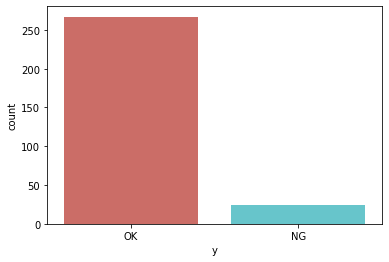

```python
sns.countplot(x='y', data=data, palette='hls')
plt.show()
```

```python
data['y']=np.where(data['y'] =='OK', 0, data['y'])
data['y']=np.where(data['y'] =='NG', 1, data['y'])
data['y'] = data['y'].astype('int')
data.head(5)
```

|  | y | 0 | 1 | 2 | 3 | 4 | 5 | 6 | 7 | 8 | ... | 774 | 775 | 776 | 777 | 778 | 779 | 780 | 781 | 782 | 783 |
| --- | --- | --- | --- | --- | --- | --- | --- | --- | --- | --- | --- | --- | --- | --- | --- | --- | --- | --- | --- | --- | --- |
| 226 | 0 | 0.066667 | 0.070588 | 0.066667 | 0.070588 | 0.070588 | 0.066667 | 0.070588 | 0.066667 | 0.066667 | ... | 0.070588 | 0.070588 | 0.070588 | 0.070588 | 0.070588 | 0.070588 | 0.066667 | 0.066667 | 0.066667 | 0.066667 |
| 16 | 1 | 0.050980 | 0.054902 | 0.054902 | 0.054902 | 0.054902 | 0.054902 | 0.054902 | 0.054902 | 0.054902 | ... | 0.058824 | 0.058824 | 0.054902 | 0.054902 | 0.054902 | 0.054902 | 0.054902 | 0.054902 | 0.054902 | 0.054902 |
| 209 | 0 | 0.062745 | 0.062745 | 0.066667 | 0.066667 | 0.066667 | 0.066667 | 0.066667 | 0.066667 | 0.066667 | ... | 0.066667 | 0.066667 | 0.066667 | 0.066667 | 0.066667 | 0.062745 | 0.062745 | 0.062745 | 0.062745 | 0.062745 |
| 171 | 0 | 0.050980 | 0.050980 | 0.050980 | 0.050980 | 0.054902 | 0.054902 | 0.050980 | 0.054902 | 0.054902 | ... | 0.054902 | 0.054902 | 0.054902 | 0.054902 | 0.054902 | 0.058824 | 0.054902 | 0.058824 | 0.058824 | 0.054902 |
| 118 | 0 | 0.050980 | 0.050980 | 0.050980 | 0.050980 | 0.054902 | 0.054902 | 0.054902 | 0.050980 | 0.054902 | ... | 0.054902 | 0.054902 | 0.054902 | 0.054902 | 0.050980 | 0.054902 | 0.054902 | 0.050980 | 0.050980 | 0.050980 |

5 rows × 785 columns

```python
X = data.loc[:, data.columns != 'y']
y = data.loc[:, data.columns == 'y']
y = y.astype('int')
```

# Over-sampling using SMOTE

```python
from sklearn.model_selection import train_test_split
from imblearn.over_sampling import SMOTE

os = SMOTE(random_state=0)

columns = X.columns
os_data_X,os_data_y=os.fit_sample(X, y)
os_data_X = pd.DataFrame(data=os_data_X,columns=columns )
os_data_y= pd.DataFrame(data=os_data_y,columns=['y'])

# we can Check the numbers of our data
print("length of oversampled data is ",len(os_data_X))
print("Number of OK images in oversampled data",len(os_data_y[os_data_y['y']==0]))
print("Number of NG images in oversampled data",len(os_data_y[os_data_y['y']==1]))
print("Proportion of OK data in oversampled data is ",len(os_data_y[os_data_y['y']==0])/len(os_data_X))
print("Proportion of NG data in oversampled data is ",len(os_data_y[os_data_y['y']==1])/len(os_data_X))
```

```
length of oversampled data is  534
Number of OK images in oversampled data 267
Number of NG images in oversampled data 267
Proportion of OK data in oversampled data is  0.5
Proportion of NG data in oversampled data is  0.5
```

# Recursive Feature Elimination

```python
from sklearn.linear_model import LogisticRegression
from sklearn import preprocessing
from sklearn.feature_selection import RFE
from sklearn.linear_model import LogisticRegression
logreg = LogisticRegression()
rfe = RFE(logreg, 10)
rfe = rfe.fit(os_data_X, os_data_y.values.ravel())
print(rfe.support_)
print(rfe.ranking_)
```

[output not shown]

[output cut: 55 more lines]

```
  51   9  43 138 128   1 149 473 554 266 651 486 404 433 760 758 125  56
 113  10 216  49 108 122  54 151 666 324  15  77 360 434 655 253 432 512
 540 330 740 579 489 662 665 291 353  33 448 229 350 405 129  46   1  19
  84 309 146 137 159 158 134 521 551 505 369 267 553 689 530 242 583 639
 296 263 212 246   1   1   1  30 454 234  68   1  80 366 470 374 737 526
 593 678 618 635 576 557 563 257 511 684 638 714 620 275 478 344 147 203
 729 320 319 416 168 352 613 354 323 329 715 771 733 365 428 472 260 446
 183 441 667 524 669 768 456 295 200 175 414 314 457 562 487 447 523 539
 347 318 345 513 423 364 572 343 371 322 338 198 224 575 479 437 383 370
 514 332 548 510 673 570 559 628 543 491 502 430 411 444 391 195 317 179
 221 585 492 399 304 461 507 255 693 438 463 659 656 566 436 606 697 670
 577 623 388 591 284 490 387 307 301 244 290 248 462 306 334 398 429 413
 450 749 718 677 601 531 468 704 418 271 484 407 452 421 278 417 349 336
 611 385 326 193 459 302 233 219 213 710 586 732 772 719 734 745 636 485
 504 425 337 578 400 466 259 258 406 254]
```

```python
df1 = pd.DataFrame({
    'Feature': X.columns,
    'Importance': rfe.ranking_},)
df1.sort_values(by=['Importance'])
```

|  | Feature | Importance |
| --- | --- | --- |
| 245 | 245 | 1 |
| 204 | 204 | 1 |
| 527 | 527 | 1 |
| 500 | 500 | 1 |
| 605 | 605 | 1 |
| ... | ... | ... |
| 641 | 641 | 771 |
| 768 | 768 | 772 |
| 4 | 4 | 773 |
| 96 | 96 | 774 |
| 110 | 110 | 775 |

784 rows × 2 columns

```python
cols=[]
for i in range (0, len(df1["Importance"])):
    if df1["Importance"][i] == 1:
        cols.append(df1["Feature"][i])
print(cols)
print(len(cols))
```

```
[204, 245, 246, 500, 527, 574, 598, 599, 600, 605]
10
```

```python
X=os_data_X[cols]
y=os_data_y['y']
```

# Implementing the model

```python
import statsmodels.api as sm
logit_model=sm.Logit(y,X)
result=logit_model.fit()
print(result.summary2())
```

```
Optimization terminated successfully.
         Current function value: 0.407107
         Iterations 7
                         Results: Logit
=================================================================
Model:              Logit            Pseudo R-squared: 0.413
Dependent Variable: y                AIC:              454.7899
Date:               2022-04-28 22:21 BIC:              497.5939
No. Observations:   534              Log-Likelihood:   -217.39
Df Model:           9                LL-Null:          -370.14
Df Residuals:       524              LLR p-value:      1.7851e-60
Converged:          1.0000           Scale:            1.0000
No. Iterations:     7.0000
-------------------------------------------------------------------
        Coef.     Std.Err.      z      P>|z|     [0.025     0.975]
-------------------------------------------------------------------
204    -27.0343     3.9674   -6.8142   0.0000   -34.8102   -19.2584
245      5.6161     5.0602    1.1099   0.2671    -4.3016    15.5338
246    -35.7814     8.9821   -3.9837   0.0001   -53.3860   -18.1769
500     -3.6835     5.5635   -0.6621   0.5079   -14.5877     7.2206
527     -3.4340     3.9846   -0.8618   0.3888   -11.2436     4.3757
574     86.4907     7.5373   11.4750   0.0000    71.7178   101.2635
598    -20.5908     8.3983   -2.4518   0.0142   -37.0512    -4.1304
599     17.5410    10.5856    1.6571   0.0975    -3.2064    38.2884
600    -22.6480     6.4439   -3.5146   0.0004   -35.2778   -10.0181
605    -11.7327     2.9976   -3.9140   0.0001   -17.6079    -5.8575
=================================================================
```

```python
pvalue = pd.DataFrame(result.pvalues,columns={'p_value'},)
pvalue
```

|  | p_value |
| --- | --- |
| 204 | 9.479725e-12 |
| 245 | 2.670546e-01 |
| 246 | 6.786474e-05 |
| 500 | 5.079107e-01 |
| 527 | 3.887932e-01 |
| 574 | 1.761258e-30 |
| 598 | 1.421508e-02 |
| 599 | 9.750684e-02 |
| 600 | 4.403815e-04 |
| 605 | 9.077791e-05 |

```python
pvalue1 = list(pvalue["p_value"])
pvalue2 = list(pvalue.index)
pvs=[]
for i in range (0, len(pvalue["p_value"])):
    if pvalue1[i] < 0.05:
        pvs.append(pvalue2[i])
print(pvs)
print(len(pvs))
```

```
[204, 246, 574, 598, 600, 605]
6
```

```python
X=os_data_X[pvs]
y=os_data_y['y']
logit_model=sm.Logit(y,X)
result=logit_model.fit()
print(result.summary2())
```

```
Optimization terminated successfully.
         Current function value: 0.420985
         Iterations 7
                         Results: Logit
=================================================================
Model:              Logit            Pseudo R-squared: 0.393
Dependent Variable: y                AIC:              461.6117
Date:               2022-04-28 22:21 BIC:              487.2941
No. Observations:   534              Log-Likelihood:   -224.81
Df Model:           5                LL-Null:          -370.14
Df Residuals:       528              LLR p-value:      1.0146e-60
Converged:          1.0000           Scale:            1.0000
No. Iterations:     7.0000
-------------------------------------------------------------------
        Coef.     Std.Err.      z      P>|z|     [0.025     0.975]
-------------------------------------------------------------------
204    -27.9490     3.8084   -7.3388   0.0000   -35.4133   -20.4847
246    -29.7672     5.3099   -5.6060   0.0000   -40.1743   -19.3601
574     83.5993     7.3510   11.3724   0.0000    69.1915    98.0070
598     -7.8594     3.9710   -1.9792   0.0478   -15.6425    -0.0763
600    -16.9797     4.8397   -3.5084   0.0005   -26.4652    -7.4941
605    -12.5415     2.9863   -4.1997   0.0000   -18.3944    -6.6886
=================================================================
```

# Logistic Regression Model Fitting

```python
from sklearn.linear_model import LogisticRegression
from sklearn import metrics
X_train, X_test, y_train, y_test = train_test_split(X, y, test_size=0.33, random_state=0, stratify=y)
logreg = LogisticRegression(random_state=0)
logreg.fit(X_train, y_train)
```

```
LogisticRegression(random_state=0)
```

```python
y_pred = logreg.predict(X_test)
print('Accuracy of logistic regression classifier on test set: {:.2f}'.format(logreg.score(X_test, y_test)))
```

```
Accuracy of logistic regression classifier on test set: 0.83
```

# Confusion Matrix

```python
from sklearn.metrics import confusion_matrix
confusion_matrix = confusion_matrix(y_test, y_pred)
print(confusion_matrix)
```

```
[[75 14]
 [16 72]]
```

# Compute precision, recall, F-measure and support

```python
from sklearn.metrics import classification_report
print(classification_report(y_test, y_pred))
```

```
              precision    recall  f1-score   support

           0       0.82      0.84      0.83        89
           1       0.84      0.82      0.83        88

    accuracy                           0.83       177
   macro avg       0.83      0.83      0.83       177
weighted avg       0.83      0.83      0.83       177
```

# ROC Curve

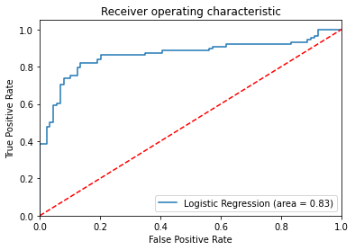

```python
from sklearn.metrics import roc_auc_score
from sklearn.metrics import roc_curve
logit_roc_auc = roc_auc_score(y_test, logreg.predict(X_test))
fpr, tpr, thresholds = roc_curve(y_test, logreg.predict_proba(X_test)[:,1])
plt.figure()
plt.plot(fpr, tpr, label='Logistic Regression (area = %0.2f)' % logit_roc_auc)
plt.plot([0, 1], [0, 1],'r--')
plt.xlim([0.0, 1.0])
plt.ylim([0.0, 1.05])
plt.xlabel('False Positive Rate')
plt.ylabel('True Positive Rate')
plt.title('Receiver operating characteristic')
plt.legend(loc="lower right")
plt.show()
```

```python
import shutil
dir_path = 'C:\\Users\\רועי\\data\\NG-vs-OK\\DA1'
shutil.rmtree(dir_path)
```